# Inhomogeneity Correction

## MS Lesion

Let’s reset and read in the T1 image from a MS lesion data set:

```r
t1 = neurobase::readnii("training01_01_t1.nii.gz")
t1[ t1 < 0 ] = 0
```

## Overall Pipeline

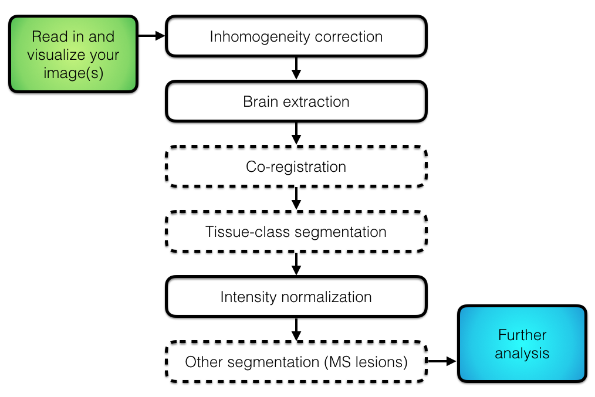

## Inhomogeneity correction

- Scans can have nonuniform intensities throughout the brain
- Usually low frequency - smooth over the brain (assumed)
- Referred to as bias, bias field, or inhomogeneity

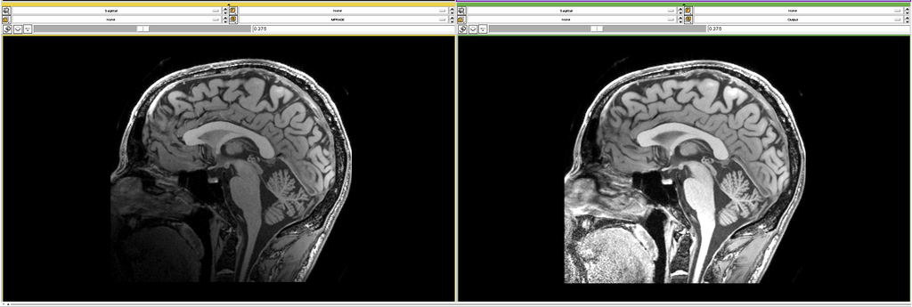

Image From https://www.slicer.org/w/images/7/77/MRI_Bias_Field_Correction_Slicer3_close_up.png

## Image Data

It’s hard to see subtler bias fields, but sometimes they can be seen visually.

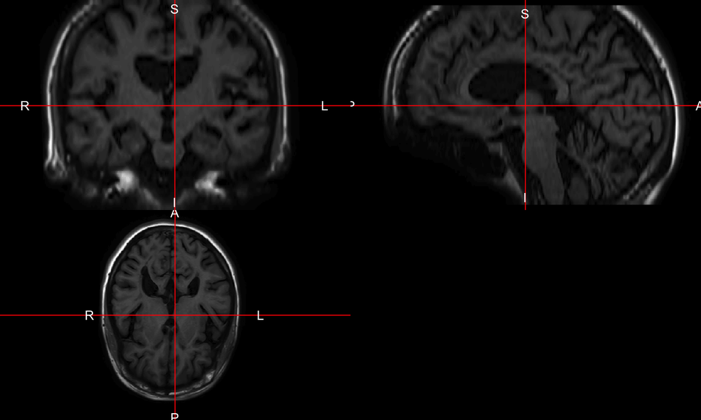

```r
ortho2(robust_window(t1))
```

## Image Data

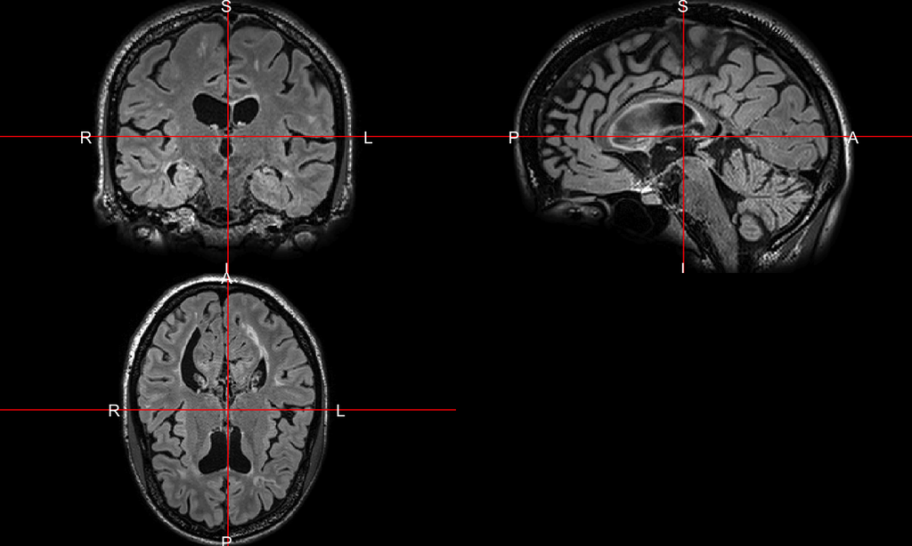

```r
flair = neurobase::readnii("training01_01_flair.nii.gz")
ortho2(robust_window(flair))
```

## Image Data: Lightbox

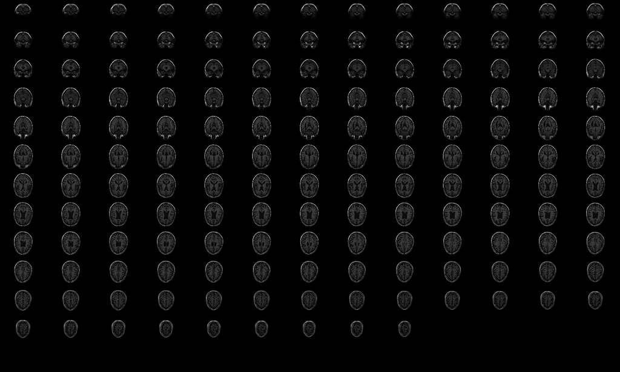

```r
image(robust_window(t1), useRaster = TRUE)
```

## N4 Inhomogeneity Correction

We will use N4: Improved N3 Bias Correction (Tustison et al. 2010).

The model assumed in the N4 is: \[ v(x) = u(x)f(x) + n(x) \]

- \(v\) is the given image
- \(u\) is the uncorrupted image
- \(f\) is the bias field
- \(n\) is the noise (assumed to be independent and Gaussian)
- \(x\) is a location in the image

## N4 Inhomogeneity Correction

The data is log-transformed and assuming a noise-free scenario, we have:

\[ \log(v(x)) = \log(u(x)) + \log( f(x) ) \]

- N4 uses a B-spline approximation of the bias field
- It iterates until a convergence criteria is met
  - when the updated bias field is the same as the last iteration
- It outputs the data back in the original units (not log-transformed)

## Bias Field Correction

Here we will use the `bias_correct` function in `extrantsr`, which calls `n4BiasFieldCorrection` from `ANTsR`.

You can pass in the image:

```r
library(extrantsr)
bc_t1 = bias_correct(file = t1, correction = "N4")
```

or the filename (but negatives are in there):

```r
bc_t1 = bias_correct(file = "training01_01_t1.nii.gz", correction = "N4")
```

## Visualizing Bias Field Correction

Here we take the ratio of the images and overlay it on the original image:

```r
ratio = t1 / bc_t1; ortho2(t1, ratio)
```

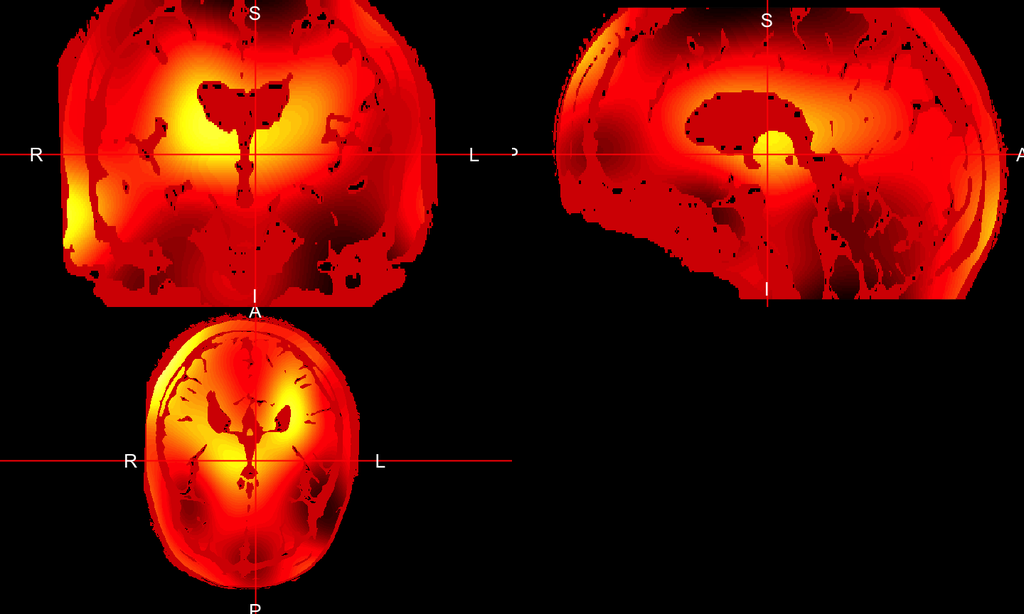

## Visualizing Bias Field Correction

We are breaking the ratio into quantiles:

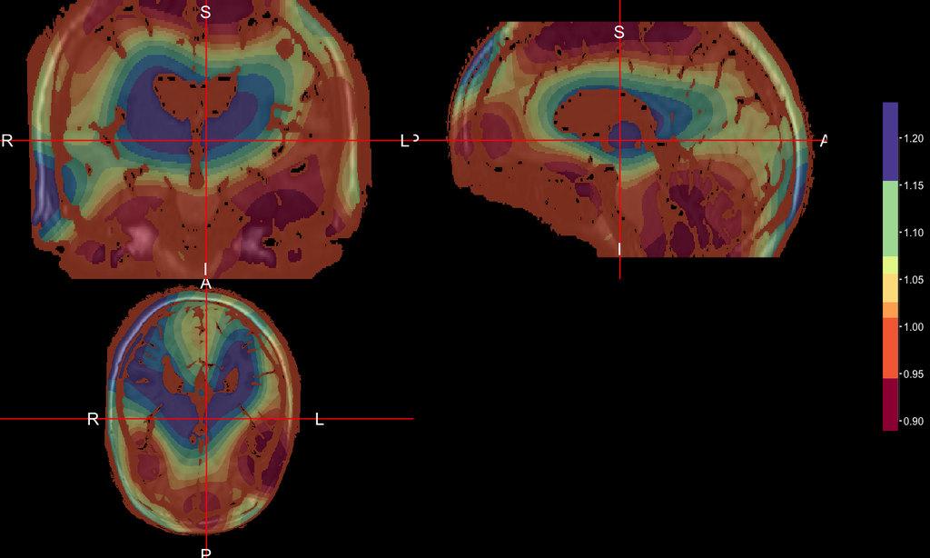

```r
ortho2(t1, ratio, col.y = colors, ybreaks = quantiles, ycolorbar = TRUE)
```

## Conclusions

- Inhomogeneity correction is one of the first steps of most structural MRI pipelines
- Inhomogeneity can cause problems for other methods/segmentation
- Corrections try to make tissues of the same class to have similar intensities
- Use the `extrantsr` `bias_correct` function
  - There is also `fsl_biascorrect` from `fslr` (not as effective in our experience)
- You may also want to run corrections after skull stripping on the brain only
  - this is possible with the result after the brain extraction lecture
  - correction before skull-stripping may be necessary and can improve after correction

## Website

http://johnmuschelli.com/imaging_in_r

## References

Tustison, Nicholas J., Brian B. Avants, Philip A. Cook, Yuanjie Zheng, Alexander Egan, Paul A. Yushkevich, and James C. Gee. 2010. “N4ITK: Improved N3 Bias Correction.” *IEEE Transactions on Medical Imaging* 29 (6):1310–20. https://doi.org/10.1109/TMI.2010.2046908.